# SimmsFishFence

Eric V

2024-11-10

# 1. Introduction

Simms Creek is a small, 3rd order stream that drains an area of ~1,800 ha into the Salish Sea, near Campbell River’s Willow Point neighborhood. The lower reach of Simms Creek (~3 km of channel, east of Jubilee Road), is contained within a narrow urban green way that is bordered by residential properties. From Jubilee Road to the Inland Highway the stream is protected within [Beaver Lodge Lands](https://campbellriver.travel/news/forestry-guide-to-beaver-lodge-lands/), upstream of the Inland Highway, >1.5 km of tributary channel is located within private forest lands.

Historic fish observations indicate that Chum, Chinook, Pink and Coho Salmon have all been observed in the stream, as well as Coastal Cutthroat Trout, Rainbow Trout and Steelhead. More recent monitoring (aka this dataset), suggest that Coho Salmon and Coastal Cutthroat Trout are the primary species within Simms Creek, both of which utilize the stream year round - though a small number of juvenile Chinook Salmon were identified in 2024.

[Greenways Land Trust](https://www.greenwaystrust.ca/) has supported Simms Creek Stewards for +20 years, including operation of a fish fence near the mouth of the stream since 2008. Juvenile and adult fish moving past the fence are tallied each spring and fall, respectively. The objective of this project is to explore the juvenile fence dataset. All work is being done strictly for fun and out of personal curiosity. Any feedback, input, or support is welcome. Also, I have a soft spot for Coastal Cutthroat Trout (CCT), so be warned that effort may be slightly trout biased.

Throughout this analysis, I will aim to answer the following questions:

1. What species are utilizing Simms Creek?
2. Is current fence operation program capturing the complete migration period?
3. For each species, when are key behaviours occuring (e.g., when is peak smolt? when do adults arrive?).
4. How large are fish encountered during smolt and upstream migration periods? What age classes are migrating (I don’t have scale data, but we can make an educated guess).
5. What is the freshwater survival of Coho Salmon? Note that we cannot estimate marine survival without some information on individual fish (i.e., coded wire tag data to verify that returning adults originated in Simms Creek and when they smolted).
6. What proportion of returning Coho Salmon are hatchery origin? Have any hatchery origin trout been encountered (not actually sure if there are many hatchery reared trout at the moment, and if so, if they are marked).
7. What factors may be contributing to observed trends in abundance?

But before we can do that, lets take a look at what has been completed to date. It’s a tremendous amount of work and all volunteers and supporters should be commended!

# 2. Spring Fence Operation

### 2.1. Monitoring Effort

The Simms Creek fish fence has operated annually since 2008, with the exception of 2020 and 2021 when operations were paused due to the COVID-19 Pandemic and in the spring of 2023 when federal employees were on strike.

Spring surveys target out migrating juvenile Coho Salmon but also capture an impressive number of Coastal Cutthroat Trout and have even captured some Chinook Salmon. Spring fence monitoring has started as early as April 03, however, most surveys (50%) don’t start until April 18. In each monitoring year, the fence has operated continuously (e.g., sampling occurred at least daily) from April 28 to May 30. Surveys have continued as late as June 13, but most (50%) are terminated by June 06.

Table 1. Annual spring and fall trap operation periods.

Spring Sampling

Fall Sampling

Year

# Days Sampled

Start

End

# Days Sampled

Start

End

2008

41

Apr-21

May-31

40

Oct-14

Nov-22

2009

50

Apr-19

Jun-07

40

Oct-14

Nov-22

2010

42

Apr-19

May-30

35

Oct-23

Nov-26

2011

49

Apr-19

Jun-06

46

Oct-18

Dec-02

2012

50

Apr-16

Jun-04

50

Oct-14

Dec-02

2013

49

Apr-14

Jun-01

62

Sep-29

Dec-01

2014

45

Apr-24

Jun-07

58

Oct-04

Nov-30

2015

52

Apr-10

May-31

62

Oct-08

Dec-08

2016

63

Apr-03

Jun-04

60

Oct-07

Dec-05

2017

68

Apr-05

Jun-11

56

Oct-11

Dec-05

2018

52

Apr-21

Jun-11

58

Oct-08

Dec-04

2019

51

Apr-18

Jun-07

64

Oct-08

Dec-10

2020

0

COVID

0

2021

0

COVID

0

2022

47

Apr-28

Jun-13

37

Oct-11

Nov-16

2023

0

DFO Strike

45

Sep-26

Nov-17

2024

55

Apr-12

Jun-05

0

Figure 1. Spring juvenile trap operation effort, presented as the proportion of sample years when trapping was completed on each date.

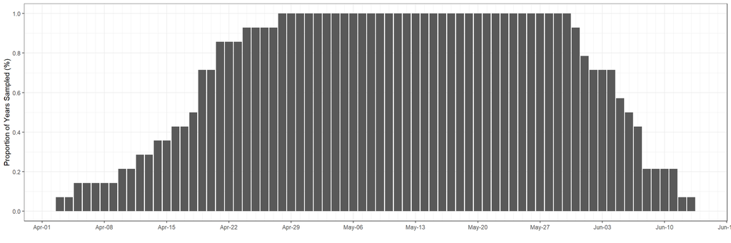

Figure 2. Fall adult trapping effort, presented as the proportion of sample years when trapping was completed on each date.

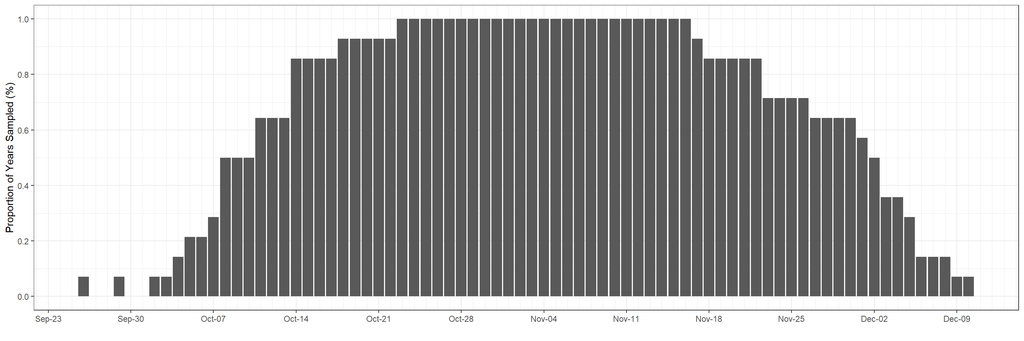

### 2.2 Stream Conditions

Table 2. Stream conditions during spring trap operation.

Year

Spring Monitoring

Air Temp.  
(°C)

Water Temp.  
(°C)

pH  
.

DO  
(mg/L)

TDS  
(ppm)

Water Level  
(m)

Mean

SD

Mean

SD

Mean

SD

Mean

SD

Mean

SD

Mean

SD

2008

9.5

4.0

10.5

2.8

7.1

0.3

10.8

0.8

67.8

36.8

0.2

0.0

2009

11.8

3.0

10.3

2.4

7.1

0.2

10.3

0.8

136.4

26.2

0.3

0.0

2010

9.5

2.2

10.0

1.6

8.2

0.3

10.5

1.8

110.2

17.4

0.2

0.1

2011

9.8

2.3

9.8

2.1

6.7

0.3

9.1

1.0

95.5

11.7

0.2

0.0

2012

11.0

2.1

10.2

1.7

7.4

0.8

9.9

1.4

99.4

17.2

0.2

0.1

2013

10.3

2.9

10.1

2.0

7.9

0.3

11.5

0.9

100.6

14.9

0.2

0.1

2014

12.2

2.4

11.3

1.7

8.1

0.5

9.7

0.6

97.8

19.2

0.2

0.1

2015

10.5

3.4

11.0

2.5

8.1

0.2

9.4

0.8

106.7

22.2

0.2

0.4

2016

11.4

2.8

11.7

1.8

7.1

0.4

10.2

1.5

111.3

20.1

0.1

0.0

2017

9.6

3.0

10.2

2.3

8.2

0.4

10.9

2.2

77.8

25.6

0.3

0.1

2018

10.7

2.5

8.7

1.3

8.8

1.4

14.2

1.6

153.9

21.2

0.1

0.0

2019

11.2

2.7

11.9

2.3

8.0

0.2

8.6

0.7

129.0

25.7

0.1

0.1

2022

11.7

2.5

12.2

16.0

7.5

0.3

83.0

17.2

0.2

0.1

2023

2024

12.1

2.2

10.3

2.1

7.7

0.4

10.2

0.9

129.8

30.0

0.1

0.0

Figure 3. Average daily measures of air and water temperature, pH, dissolved oxygen (DO), total dissolved solids (TDS) and water level (stage).

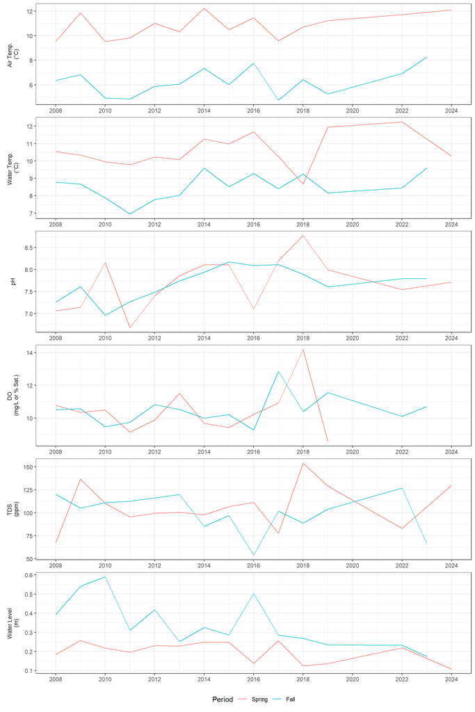

### 2.3. Annual Captures

Since 2008, a total of 5,046 juvenile Coastal Cutthroat Trout and 8,216 juvenile Coho Salmon have been captured during spring trapping. Annual captures of CCT have ranged from 45 to 849 (mean = 360) while CO captures have varied from 335 to 913 with an overall mean of 587) fish (Figure 4 and Table 4).

Figure 4. Total annual catch of Coastal Cutthroat Trout and Coho Salmon during Spring fence monitoring.

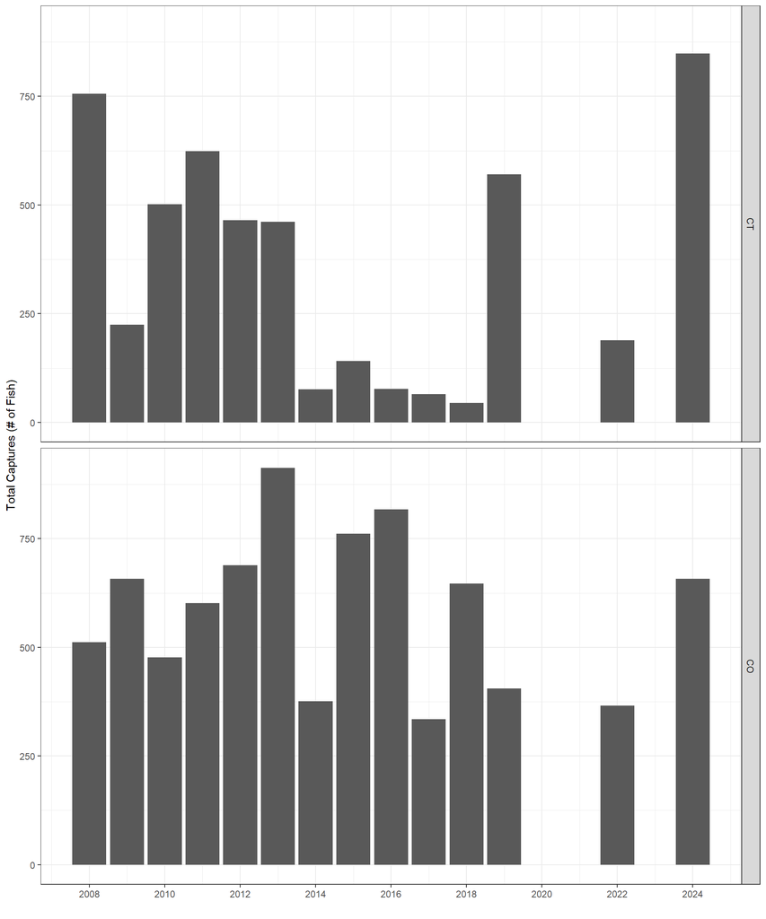

**Table 4. Spring capture summary - capture timing, total captures and length of Coastal Cutthroat Trout and Coho Salmon.**

| Year | Sample Period Start | Sample Period End | Sample Period # Days Sampled | Coastal Cutthroat Trout Capture Timing Med. | Coastal Cutthroat Trout Capture Timing Min | Coastal Cutthroat Trout Capture Timing Max | Coastal Cutthroat Trout Fork Length (mm) n | Coastal Cutthroat Trout Fork Length (mm) Mean | Coastal Cutthroat Trout Fork Length (mm) SD | Coastal Cutthroat Trout Fork Length (mm) Min | Coastal Cutthroat Trout Fork Length (mm) Max | Coho Salmon Capture Timing Med. | Coho Salmon Capture Timing Min | Coho Salmon Capture Timing Max | Coho Salmon Fork Length (mm) n | Coho Salmon Fork Length (mm) Mean | Coho Salmon Fork Length (mm) SD | Coho Salmon Fork Length (mm) Min | Coho Salmon Fork Length (mm) Max |
| --- | --- | --- | --- | --- | --- | --- | --- | --- | --- | --- | --- | --- | --- | --- | --- | --- | --- | --- | --- |
| 2008 | Apr-21 | May-31 | 41 | May-20 | Apr-21 | May-31 | 756 | 139.1 | 27.6 | 90 | 280 | May-17 | Apr-25 | May-31 | 512 | 118.1 | 10.7 | 84.0 | 150 |
| 2009 | Apr-19 | Jun-07 | 50 | May-16 | Apr-20 | Jun-03 | 225 | 163.3 | 22.9 | 115 | 265 | May-20 | Apr-24 | Jun-07 | 658 | 100.2 | 11.0 | 11.0 | 160 |
| 2010 | Apr-19 | May-30 | 42 | May-13 | Apr-19 | May-29 | 502 | 149.7 | 26.1 | 110 | 285 | May-13 | Apr-20 | May-30 | 477 | 118.0 | 15.7 | 80.0 | 183 |
| 2011 | Apr-19 | Jun-06 | 49 | May-15 | Apr-23 | Jun-05 | 624 | 155.3 | 32.5 | 95 | 400 | May-17 | Apr-20 | Jun-06 | 602 | 113.1 | 12.8 | 80.0 | 147 |
| 2012 | Apr-16 | Jun-04 | 50 | May-08 | Apr-23 | Jun-01 | 465 | 160.1 | 33.7 | 80 | 335 | May-13 | Apr-16 | Jun-04 | 689 | 107.8 | 12.4 | 75.0 | 145 |
| 2013 | Apr-14 | Jun-01 | 49 | May-09 | Apr-16 | May-30 | 461 | 161.4 | 26.5 | 95 | 350 | May-12 | Apr-15 | Jun-01 | 913 | 106.7 | 9.9 | 83.0 | 150 |
| 2014 | Apr-24 | Jun-07 | 45 | May-09 | Apr-27 | Jun-02 | 76 | 142.1 | 29.2 | 70 | 310 | May-12 | Apr-26 | Jun-05 | 376 | 103.2 | 12.4 | 80.0 | 223 |
| 2015 | Apr-10 | May-31 | 52 | May-09 | Apr-15 | May-28 | 141 | 158.1 | 37.4 | 85 | 260 | May-13 | Apr-11 | May-31 | 761 | 109.3 | 11.7 | 78.0 | 152 |
| 2016 | Apr-03 | Jun-04 | 63 | Apr-26 | Apr-05 | May-15 | 77 | 147.5 | 37.4 | 88 | 250 | May-05 | Apr-05 | Jun-04 | 817 | 108.0 | 13.4 | 0.0 | 162 |
| 2017 | Apr-05 | Jun-11 | 68 | May-24 | Apr-20 | Jun-09 | 65 | 185.1 | 64.0 | 120 | 470 | May-20 | Apr-05 | Jun-11 | 335 | 113.4 | 12.8 | 80.0 | 162 |
| 2018 | Apr-21 | Jun-11 | 52 | May-04 | Apr-26 | May-27 | 45 | 167.4 | 28.2 | 120 | 230 | May-19 | Apr-21 | Jun-11 | 647 | 101.4 | 11.1 | 9.0 | 170 |
| 2019 | Apr-18 | Jun-07 | 51 | May-06 | Apr-18 | May-30 | 571 | 146.1 | 27.6 | 95 | 260 | May-13 | Apr-24 | Jun-05 | 405 | 115.4 | 12.9 | 10.7 | 152 |
| 2022 | Apr-28 | Jun-13 | 47 | May-19 | Apr-29 | Jun-13 | 189 | 168.5 | 33.6 | 98 | 430 | May-21 | Apr-28 | Jun-10 | 366 | 113.7 | 13.0 | 80.0 | 170 |
| 2024 | Apr-12 | Jun-05 | 55 | Apr-29 | Apr-17 | Jun-03 | 849 | 159.8 | 37.1 | 50 | 360 | May-10 | Apr-18 | Jun-04 | 658 | 97.5 | 17.6 | 48.0 | 174 |

### 2.4. Migration Timing

Outmigrating juvenile coastal cutthroat trout and Coho Salmon were first encountered at the trap over a similar period, from April 05 to April 29 (mean $\pm$ SD = April 19 $\pm$ 6 days) for cutthroat and April 05 to April 28 for Coho (mean $\pm$ SD = April 18 $\pm$ 7.3 days). On average 50% of all cutthroat trout had passed the fence by May 11$\pm$ 11.7 days while half of Coho Salmon migrants had passed the fence by May 15$\pm$ 6.6 days. Despite similarities in when migrations started and the timing that most migrants had past the fence, there was a noticeable difference in the timing of peak migrations (the date when the greatest number of fish passed the fence). For Coastal Cutthroat, the overall mean $\pm$ SD peak migration occurred on May 07($\pm$ 8.2 days) whereas overall mean peak Coho Salmon migration occurred more than a week later on May 15 ($\pm$ 7.1 days) (Figure 5). Total number of daily captures of Cutthroat Trout and Coho Salmon per year are presented in Figure 6 and Figure 7, respectively.

Figure 5. Histogram showing frequency of peak capture dates during Spring fence monitoring.

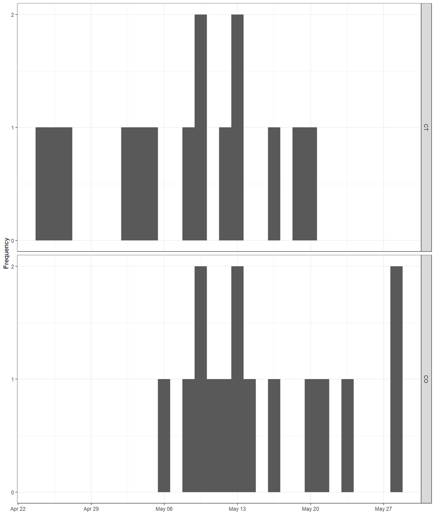

Figure 6. Number of Coastal Cutthroat Trout captured during each day of spring fence operation since 2008.

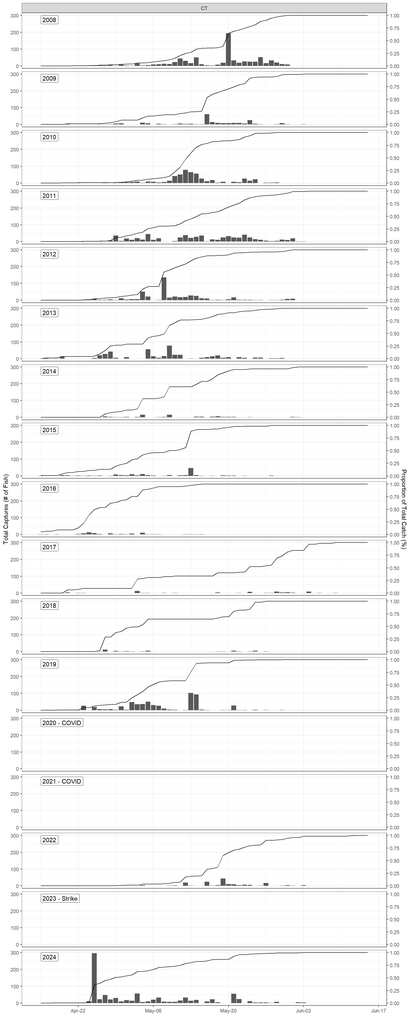

Figure 7. Number of Coho Salmon captured during each day of spring fence operation since 2008.

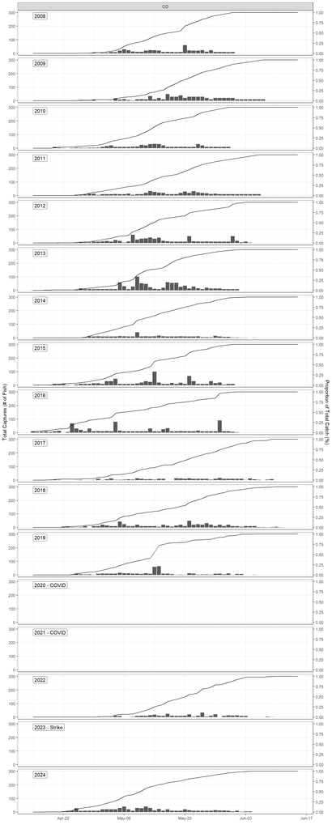

##————————–